# Analysing the first set of SILAC-based LOPIT data

```r
#---------------------------------------------------------------------------
# Author          : Manasa Ramakrishna, mr325@le.ac.uk
# Date started  : 1st June, 2017
# Last modified : 15th June, 2017
# Aim             : To take a look at first SILAC labelled LOPIT data on Trizol
# Depends       : On 'silacFunctions.R'. Make sure they are in the same directory
# Notes         : Works on data from Rayner's first experiments
#---------------------------------------------------------------------------
# Invoking libraries
library(clusterProfiler)
library(ggplot2)
library(gplots)
library(limma)
library(org.Hs.eg.db)
library(outliers)
library(RColorBrewer)
library(reshape2)
library(stringr)
#Setting working directories
wd = "/Users/manasa/Documents/Work/TTT/02_Proteomics/01_First-SILAC-LOPIT/"
setwd(wd)
getwd()
```

```
[1] "/Users/manasa/Documents/Work/TTT/02_Proteomics/01_First-SILAC-LOPIT"
```

```r
indir = paste(wd,"Input",sep="/")
outdir = paste(wd,paste(Sys.Date(),"Output",sep = "_"),sep = "/")
if (exists(outdir)){
  print("Outdir exists")
}else{
  dir.create(outdir)
}
# Sourcing function file
source("silacFunctions.R")
```

Now that we have loaded all the packages we need for working with this data, let’s move on to the data.

```r
# -----------------------------------------------
# Step 0: Read data
# Read in all the data required for analysis
# -----------------------------------------------
# File of contaminants - proteins to exclude from analysis as are things like keratin, alcohol dehydrogenase etc....
contam = read.delim("Input/Common contaminant_all.csv",sep=",",header=T)
# Read in the data files that contain peptide level output from Proteome discoverer...
# Note: I have converted the excel files to text files and removed '(02)' from the filenames to make it easier for coding. No love hearts for Excel.
# Modify the headers to be all lower case as well as remove unwanted spaces, symbols etc...to keep it simple
# Columns of interest are "sequence", "modifications","master.protein.accessions","abundance.heavy","abundance.light","abundance.ratio","quan.info"
infiles = grep("Trizol",list.files("Input/",full.names = T),value=T)
prot.data = NULL
for (i in infiles){
  in.dat = read.delim(i,sep="\t",comment.char="",as.is=T,header=F)
  in.dat$sample = strsplit(i,"//")[[1]][2]
  #print(i)
  prot.data = rbind(prot.data,in.dat)
}
colnames(prot.data) = prot.data[1,]
dim(prot.data)
```

```
[1] 81595    29
```

```r
# Remove header lines as they differ in one of the columns (fraction number I think)
remove.head = which(prot.data[,1]=="Checked")
prot.data = prot.data[-(remove.head),]
dim(prot.data)
```

```
[1] 81586    29
```

```r
# Change header names a little to make them neutral and remove space, special characters
colnames(prot.data) = tolower(colnames(prot.data))
colnames(prot.data) = gsub(" ",".",colnames(prot.data))
colnames(prot.data) = gsub("#","no",colnames(prot.data))
colnames(prot.data) = gsub("\\:\\.f2\\:","n",colnames(prot.data))
colnames(prot.data)[12] = "theoretical.mass"
colnames(prot.data)[13] = "light.sample"
colnames(prot.data)[14] = "heavy.sample"
colnames(prot.data)[15] = "abundance.ratio.heavy.to.light"
colnames(prot.data)[16] = "abundance.light"
colnames(prot.data)[17] = "abundance.heavy"
colnames(prot.data)[29] = "sample"
# Convert abundance values to numeric from character
prot.data$abundance.heavy = as.numeric(prot.data$abundance.heavy)
prot.data$abundance.light = as.numeric(prot.data$abundance.light)
prot.data$abundance.ratio.heavy.to.light = as.numeric(prot.data$abundance.ratio.heavy.to.light)
# Add rep, reagent and UV amount columns
prot.data$uv = sapply(strsplit(prot.data$sample,"_"),"[[",2)
prot.data$repl = gsub(".txt","",gsub("rep","",sapply(strsplit(prot.data$sample,"_"),"[[",3)))
prot.data$repl = paste(prot.data$uv,prot.data$rep,sep=".")
prot.data$reagent = sapply(strsplit(prot.data$sample,"_"),"[[",1)
head(prot.data)
```

|  | checked | confidence | sequence | modifications | qvality.pep | qvality.q-value | no.protein.groups | no.proteins | no.psms | master.protein.accessions | no.missed.cleavages | theoretical.mass | light.sample | heavy.sample | abundance.ratio.heavy.to.light | abundance.light | abundance.heavy | quan.info | amanda.score.ms.amanda | confidence.ms.amanda | search.space.ms.amanda | percolator.q-value.ms.amanda | percolator.pep.ms.amanda | ions.score.mascot | confidence.mascot | search.space.mascot | percolator.q-value.mascot | percolator.pep.mascot | sample | … |
| --- | --- | --- | --- | --- | --- | --- | --- | --- | --- | --- | --- | --- | --- | --- | --- | --- | --- | --- | --- | --- | --- | --- | --- | --- | --- | --- | --- | --- | --- | --- |
| 2 | FALSE | High | AGAHLQGGAK |  | 5.61944E-06 | 0 | 1 | 2 | 16 | P04406 | 0 | 909.4900898 | High | Peak Found | 0.01 | 5200000 | 43050 | Unique | 135.209857 | High | 1636 | 0 | 0.00001018 | 65.04 | High |  | 0 | 2.945E-07 | Trizol_150mJ_rep1.txt | … |
| 3 | FALSE | High | IMNTFSVVPSPK | 1xLabel:13C(6)15N(2) [K12] | 3.4751E-06 | 0 | 4 | 11 | 8 | Q13509; P04350; P07437; P68371 | 0 | 1327.716983 | Not Found | Not Found | NA | NA | NA | No Quan Values | 201.8662137 | High | 2601 | 0 | 0.000002614 | 75.28 | High |  | 0 | 1.695E-07 | Trizol_150mJ_rep1.txt | … |
| 4 | FALSE | High | IMNTFSVVPSPK |  | 2.42801E-06 | 0 | 4 | 11 | 6 | Q13509; P04350; P07437; P68371 | 0 | 1319.702784 | Not Found | Not Found | NA | NA | NA | No Quan Values | 176.2597659 | High | 2728 | 0 | 0.00001715 | 79.87 | High |  | 0 | 1.112E-07 | Trizol_150mJ_rep1.txt | … |
| 5 | FALSE | High | NQVTQLKEQVPGFTPR |  | 0.000142696 | 0 | 1 | 2 | 4 | F5H2F4 | 1 | 1841.986822 | Not Found | Not Found | NA | NA | NA | No Quan Values | 127.0712654 | High | 3048 | 0 | 0.00005757 | 40.09 | High |  | 0 | 0.00003356 | Trizol_150mJ_rep1.txt | … |
| 6 | FALSE | High | EQELQQTLQQEQSVLDQLR |  | 1.97349E-07 | 0 | 1 | 1 | 6 | Q15149 | 0 | 2313.168093 | High | Not Found | 0.01 | 656400 | NA | Unique | 152.1398947 | High | 3758 | 0 | 1.928E-07 | 44.95 | High |  | 0 | 1.211E-08 | Trizol_150mJ_rep1.txt | … |
| 7 | FALSE | High | TTPSVVAFTADGER |  | 9.80731E-06 | 0 | 1 | 3 | 4 | P38646 | 0 | 1450.717248 | High | Not Found | NA | NA | NA | No Quan Values | 104.2831076 | High | 2414 | 0 | 0.00002452 | 48.27 | High |  | 0 | 5.664E-07 | Trizol_150mJ_rep1.txt | … |

```r
dim(prot.data)
```

```
[1] 81586    32
```

prot.data has 32 columns and 81,586 rows - each row belonging to a peptide. We now go through a series of filtering steps to obtain a dataset we can use for downstream analyses.

```r
# ---------------------------------------------------------------------------------
# Step 1 : Filter
# We perform 3 layers of filtering - unique proteins, contaminants,missing values
# ---------------------------------------------------------------------------------
# Step 1a : Filter only for those peptides that have a unique master protein. Done using column "quan.info" and titled 'Unique'
dim(prot.data)
```

```
[1] 81586    32
```

```r
peptide.stats = table(prot.data$sample,prot.data$quan.info)
peptide.stats
```

```
                        No Quan Values Not Unique Unique
  Trizol_150mJ_rep1.txt           5211        287   4088
  Trizol_150mJ_rep2.txt           3869        248   3048
  Trizol_150mJ_rep3.txt           4571        247   3483
  Trizol_275mJ_rep1.txt           5266        289   3845
  Trizol_275mJ_rep2.txt           4303        212   3091
  Trizol_275mJ_rep3.txt           6578        468   6383
  Trizol_400mJ_rep1.txt           5365        286   4129
  Trizol_400mJ_rep2.txt           5203        265   3422
  Trizol_400mJ_rep3.txt           4320        219   2890
```

```r
filt.1a = prot.data[which(prot.data$quan.info == "Unique"),]
length(which(filt.1a$quan.info == "Unique"))
```

```
[1] 34379
```

```r
dim(filt.1a) #34279 are unique proteins, 47207 are non-unique or are missing values
```

```
[1] 34379    32
```

```r
# This table is very odd. Rayner had an explanation - "High" was equivalent to "Peak found"
# but also indicates which label "heavy" or "light" is higher in abundance
# However, there are peptides where it is "High" but the peptide values are NA. Hmmm....
table(light=filt.1a$light.sample,heavy=filt.1a$heavy.sample)
```

```
            heavy
light         High Not Found Peak Found
  High           0     15810      11775
  Not Found   1672         0          0
  Peak Found  5122         0          0
```

```r
# Step 1b : Filter out those proteins that are contaminants from the contaminants list and annotate missing values
filt.1b = filt.1a[-which(filt.1a$master.protein.accessions %in% contam$Protein.Group.Accessions),]
num.contams = length(which(filt.1a$master.protein.accessions %in% contam$Protein.Group.Accessions))
# Annotate which peptides are missing heavy, light or both, abundance values
filt.1b$missing.val = rowSums(is.na(filt.1b[,c("abundance.heavy", "abundance.light")])) > 0
dim(filt.1a) # 34379 in total
```

```
[1] 34379    32
```

```r
dim(filt.1b) # 33657 filtered proteins
```

```
[1] 33657    33
```

```r
print(num.contams) # 722 contaminant proteins
```

```
[1] 722
```

```r
# Want to do some stats with missing values.
table(filt.1b$sample,filt.1b$missing.val) # More missing values in 150mJ_rep, 275mK_rep2 and 450mJ_rep3. However ration of missing/non-missing is same
```

```
                        FALSE TRUE
  Trizol_150mJ_rep1.txt  1914 2097
  Trizol_150mJ_rep2.txt  1460 1523
  Trizol_150mJ_rep3.txt  1667 1723
  Trizol_275mJ_rep1.txt  1836 1915
  Trizol_275mJ_rep2.txt  1358 1670
  Trizol_275mJ_rep3.txt  3055 3175
  Trizol_400mJ_rep1.txt  2024 2031
  Trizol_400mJ_rep2.txt  1572 1797
  Trizol_400mJ_rep3.txt  1428 1412
```

```r
round(table(filt.1b$sample,filt.1b$missing.val)/rowSums(table(filt.1b$sample,filt.1b$missing.val))*100,2)
```

```
                        FALSE  TRUE
  Trizol_150mJ_rep1.txt 47.72 52.28
  Trizol_150mJ_rep2.txt 48.94 51.06
  Trizol_150mJ_rep3.txt 49.17 50.83
  Trizol_275mJ_rep1.txt 48.95 51.05
  Trizol_275mJ_rep2.txt 44.85 55.15
  Trizol_275mJ_rep3.txt 49.04 50.96
  Trizol_400mJ_rep1.txt 49.91 50.09
  Trizol_400mJ_rep2.txt 46.66 53.34
  Trizol_400mJ_rep3.txt 50.28 49.72
```

```r
# How many missing in heavy, how many missing in light
miss.l = table("_Missing light values_"=filt.1b$missing.val,filt.1b$light.sample)
miss.h = table("_Missing heavy values_"=filt.1b$missing.val,filt.1b$heavy.sample)
miss = cbind(miss.l,miss.h)
colnames(miss) = c("Light_High","Light_NotFound","Light_Found","Heavy_High","Heavy_NotFound","Heavy_Found")
rownames(miss) = c("notMissing","missing")
print(miss)
```

```
           Light_High Light_NotFound Light_Found Heavy_High Heavy_NotFound Heavy_Found
notMissing      11258              0        5056       5056              0       11258
missing         15644           1658          41       1699          15215         429
```

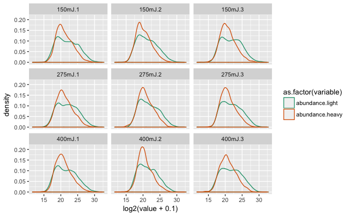

```r
# Plot density plots
melt.1b = melt(filt.1b,id.vars = "repl", measure.vars = c("abundance.light", "abundance.heavy"))
ggplot(melt.1b,aes(x = log2(value+0.1))) + geom_density(aes(col = as.factor(variable)))+facet_wrap(~repl,ncol=3)+scale_colour_brewer(palette = "Dark2")
```

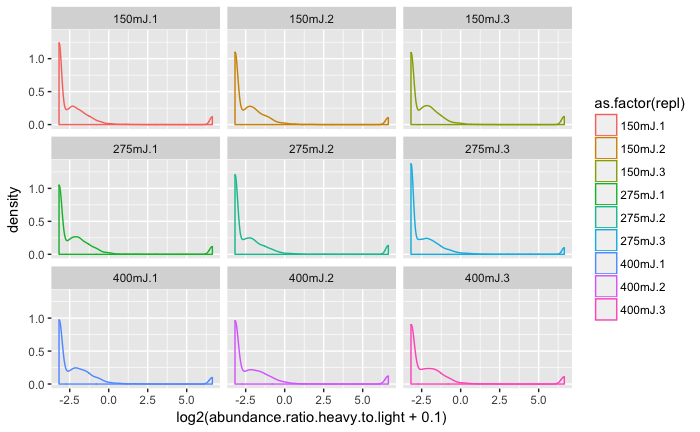

```r
ggplot(filt.1b,aes(x = log2(abundance.ratio.heavy.to.light+0.1))) + geom_density(aes(col = as.factor(repl)))+facet_wrap(~repl,ncol=3)
```

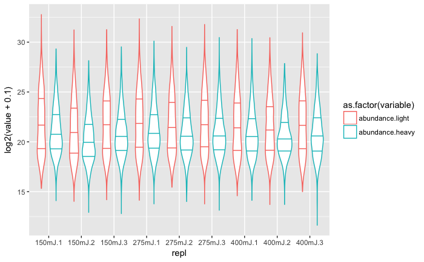

```r
ggplot(melt.1b,aes(x=repl,y = log2(value+0.1))) + geom_violin(aes(col = as.factor(variable)),draw_quantiles = c(0.25, 0.5, 0.75))
```

We have a column called “missing.val” to identify which peptides have either a heavy or light abundance value missing. TRUE means it is missing one or both. FALSE means both values are present. A lot more “missing” values in the “heavy/non-crosslinked samples than”light/cross-linked samples“.

The above plots - density plots and violin plots include both missing and non-missing values. Hence, in the heavy/light density plots, you see a huge overlap in the curve with a tiny portion of the “light” curve going beyond the heavy curve. This is where we expect the interesting RNA binding proteins to lie. The next step however is to filter out the missing values.

```r
dim(filt.1c)
```

```
[1] 16314    33
```

Note : It is important to remember that in a true experimental setting, we will not have SILAC labelling so we won’t have “heavy” and “light” values per peptide - all we will have is one abundance value. Rayner forced the mass spec to run as if it didn’t know about the SILAC labelling to parially emulate later experiments. However, we won’t be using the singleton data (heacvy only or light only) for the purposes of this initial analysis.

```r
# -----------------------------
# Step 2 : Log-transform
# heavy = non-crosslinked
# light = crosslinked
# -----------------------------
# Log convert abundance values
filt.1c$heavy.log = log(filt.1c$abundance.heavy,2)
filt.1c$light.log = log(filt.1c$abundance.light,2)
# Generate an abundance ratio which for log transformed data is a subtraction
filt.1c$norm.abundance.ratio = filt.1c$light.log - filt.1c$heavy.log
# Data is checked
norm.data = filt.1c
dim(norm.data)
```

```
[1] 16314    36
```

```r
# Checking the counts of peaks with heavy and light values
table(light=norm.data$light.sample,heavy=norm.data$heavy.sample)
```

```
            heavy
light         High Peak Found
  High           0      11258
  Peak Found  5056          0
```

Once we have filtered the data to remove non-unique peptides and contaminants, we log transform (“normalise”) the data for heavy and light abundances. In addition, we subtract the logged abundances light-heavy to yield logged abundance ratios.

When we re-draw the table of heavy and light sample counts, we don’t have any “Not Found” values anymore. This was part of the exercise.

We have 16314 peptides that are present in both fractions. Analysing the difference in ratios between these two fractions are most likely to inform on whether or not they are enriched for RNA binding proteins.

```r
# -------------------------------------------------------------
# Step 3 : Aggregating multiple peptides into a peptide group
# heavy = non-crosslinked
# light = crosslinked
# -------------------------------------------------------------
# Subset the data to include columns with useful metadata and abundance ratios
# Transform the dataframe using 'melt' so the values for heavy and light are in one column. Can use this to draw plots comparing heavy to light values when necessary.
subset.cols = norm.data[,c("master.protein.accessions","sequence","modifications","repl","uv","missing.val","light.log","heavy.log","norm.abundance.ratio")]
dim(subset.cols)
```

```
[1] 16314     9
```

```r
# Tried various methods of aggregation
# Using sequence and repeat columns to aggregate
# Using all columns but the abundance ratio columns to aggregate
# Using mean, median or max to aggregate
# Using ddply as an alternative to aggregate
# Note : Finally, settled on taking the mean of the logged values and using 'aggregate' function
# We have 15356 unique peptide groups across all samples
agg.mean = aggregate(cbind(light.log,heavy.log,norm.abundance.ratio)~sequence+repl,data=subset.cols,FUN="mean")
agg.pep.table = table(agg.mean$sequence,agg.mean$repl)
table(agg.mean$repl) # 275mJ, replicate 3 has a lot more peptide groups than other samples
```

```
150mJ.1 150mJ.2 150mJ.3 275mJ.1 275mJ.2 275mJ.3 400mJ.1 400mJ.2 400mJ.3
   1802    1366    1590    1728    1275    2882    1894    1466    1353
```

```r
# Now that peptides have been aggregated into peptide groups, re-calculate the missing value table...
write.table(agg.pep.table, paste(outdir,"Aggregated-pepides-no-missing-values.txt",sep="/"),sep="\t",quote=F)
# Will go with agg.mean for further analysis
agg = agg.mean
# I want to add protein annotations back to the aggregated data. Just want to make sure that one peptide doesn't map to multiple proteins. It shouldn't as we have only selected unique ones. Checked and is true.
for(i in 1:nrow(agg)){
  agg$num.prot[i] = length(unique(subset.cols$master.protein.accessions[which(subset.cols$sequence == agg$sequence[i] & subset.cols$repl == agg$repl[i])]))
  agg$accessions[i] = paste(unique(subset.cols$master.protein.accessions[which(subset.cols$sequence == agg$sequence[i] & subset.cols$repl == agg$repl[i])]),collapse=",")
}
head(agg)
```

|  | sequence | repl | light.log | heavy.log | norm.abundance.ratio | num.prot | accessions |
| --- | --- | --- | --- | --- | --- | --- | --- |
| 1 | AAAAAAALQAK | 150mJ.1 | 27.91815 | 24.91056 | 3.0075883 | 1 | P36578 |
| 2 | AAAETQSLR | 150mJ.1 | 26.22839 | 22.15931 | 4.0690834 | 1 | Q13523 |
| 3 | AAAMANNLQK | 150mJ.1 | 24.43873 | 20.25003 | 4.1886989 | 1 | Q14498 |
| 4 | AAEAAPPTQEAQGETEPTEQAPDALEQAADTSR | 150mJ.1 | 19.35638 | 19.07300 | 0.2833818 | 1 | Q8N163 |
| 5 | AAGPISER | 150mJ.1 | 22.39100 | 22.81245 | -0.4214498 | 1 | Q15427 |
| 6 | AAGPSLSHTSGGTQSK | 150mJ.1 | 20.91634 | 17.96804 | 2.9483034 | 1 | P27694 |

```r
table(agg.mean$repl)
```

```
150mJ.1 150mJ.2 150mJ.3 275mJ.1 275mJ.2 275mJ.3 400mJ.1 400mJ.2 400mJ.3
   1802    1366    1590    1728    1275    2882    1894    1466    1353
```

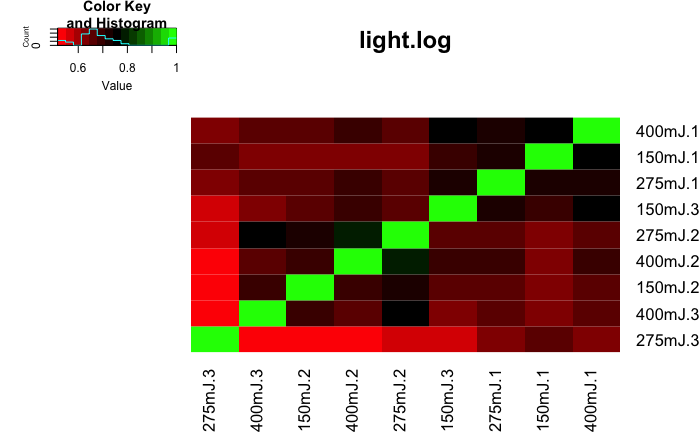

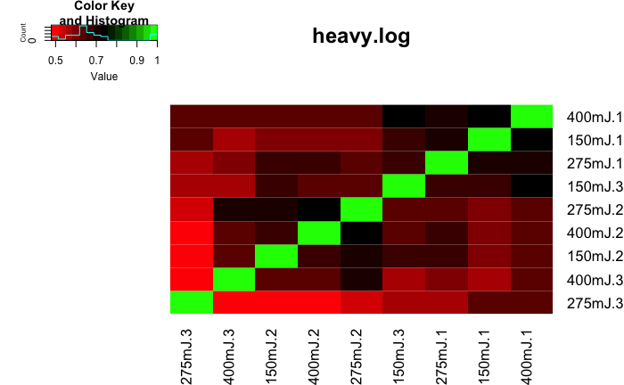

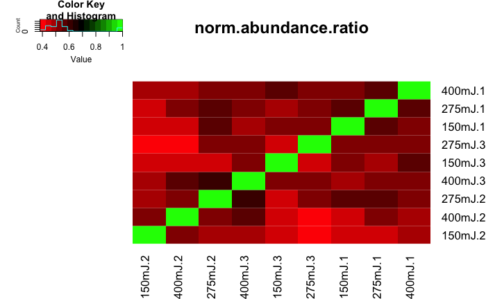

```r
# Temporarily recast data into a matrix to calculate correlations
for (t in c("light.log","heavy.log","norm.abundance.ratio")){
  m = melt(agg,id.vars = c("sequence","repl"), measure.vars = t)
  m.cast = dcast(m, sequence~repl+variable, fun.aggregate = mean)
  cor.m = cor(m.cast[,2:ncol(m.cast)],use="pairwise.complete.obs")
  colnames(cor.m) = gsub(paste("_",t,sep=""),"",colnames(cor.m))
  rownames(cor.m) = gsub(paste("_",t,sep=""),"",rownames(cor.m))
  heatmap.2(cor.m,trace = "none", dendrogram="none",col="redgreen", main=t)
}
```

Looking at the correlations for ‘heavy’ and ‘light’ abundance values across all replicates, it looks like the correlation is more within experimental replicates i.e high for rep1 of 150mJ, 275mJ, 400mJ than between 150mJ.rep1 and 150mJ.rep2 and so on.

```r
# -----------------------------------------------
# Step 4 : Aggregating multiple peptides into one protein
# heavy = non-crosslinked
# light = crosslinked
# -----------------------------------------------
# We have 1262 unique proteins across all samples
agg.prot = aggregate(cbind(light.log,heavy.log,norm.abundance.ratio)~accessions+repl,data=agg,FUN="mean")
dim(agg.prot)
```

```
[1] 5749    5
```

```r
# Table of proteins vs samples - contingency to say which protein is present in which sample.
# Will help make overlaps
agg.prot.table = table(agg.prot$accessions,agg.prot$repl)
write.table(agg.prot.table, paste(outdir,"Aggregated-proteins-no-missing-values.txt",sep="/"),sep="\t",quote=F)
table(agg.prot$repl)
```

```
150mJ.1 150mJ.2 150mJ.3 275mJ.1 275mJ.2 275mJ.3 400mJ.1 400mJ.2 400mJ.3
    676     544     600     648     511     943     696     594     537
```

```r
# -----------------------------------------------
# Step 5 : Looking for most commonly enriched proteins
# heavy = non-crosslinked
# light = crosslinked
# -----------------------------------------------
# First let us look at the intersects within and between replicates
prot.matrix = as.data.frame.matrix(agg.prot.table)
print(dim(prot.matrix))
```

```
[1] 1262    9
```

```
[1] 1
[1] 4
```

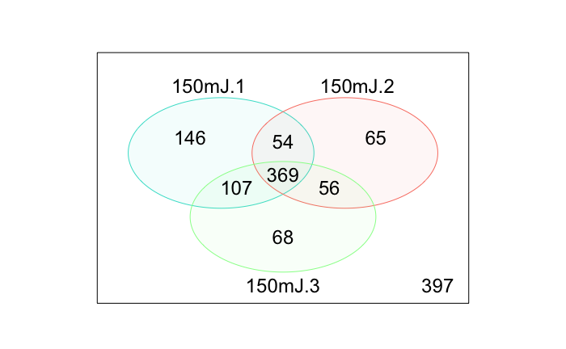

```
[1] 7
```

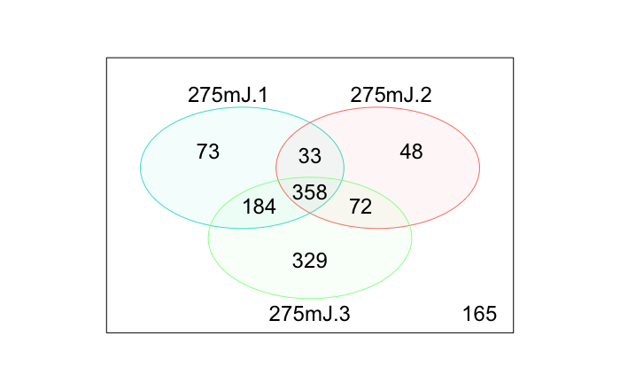

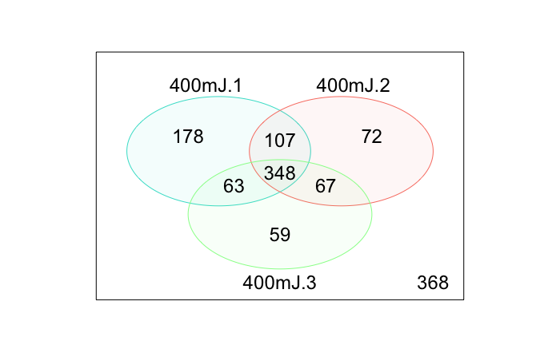

```r
# Contains counts of overlap across 9 samples in various combinations
# Most intersections not very useful except that it tell us how many proteins overlap across all 9 samples = 211
prot.venn = venn(prot.matrix,show.plot=F)
isect = attr(prot.venn,"intersections")
# table of intersections
isect.count = t(as.data.frame(lapply(isect,length)))
colnames(isect.count) = "Count"
write.table(isect.count, paste(outdir,"Count-of-protein-overlaps-across-various-samples.txt",sep="/"),sep="\t",quote=F)
# Looking at overlaps within each uv dose - the more useful intersection exercise
add.int = NULL
# Looping through each uv dosage triplicate - 1:3, 4:6, 7:9
# add.int contains all intersections for each triplicate
for(k in c(1,4,7)){
  print(k)
  prot.venn.tmp = venn(prot.matrix[,k:(k+2)],show.plot=F)
  vennDiagram(prot.matrix[,k:(k+2)],circle.col=c("turquoise", "salmon","palegreen"))
  add.int = c(add.int,attr(prot.venn.tmp,"intersections"))
}
```

```r
write.table(t(as.data.frame(lapply(add.int,length))), paste(outdir,"Count-of-protein-overlaps-within-repl-for-each-dose.txt",sep="/"),sep="\t",quote=F)
```

```r
isect[280]
```

```
$`150mJ.1:150mJ.2:150mJ.3:275mJ.1:275mJ.2:275mJ.3:400mJ.1:400mJ.2:400mJ.3`
  [1] "A0A024R4E5" "A0A087WUT6" "A0A087WVQ6" "A0A087X0X3" "A0A0A0MRV0" "A0A0C4DG17" "A0A0C4DG49" "A0A0D9SF53" "A0A0G2JNW7" "A0A0U1RRM4" "A8MXP9"     "E7EVA0"     "F5H2F4"     "F8W930"     "G8JLB6"
 [16] "H3BLZ8"     "J3KPP4"     "J3KTA4"     "M0QYS1"     "O00203"     "O00567"     "O15479"     "O43175"     "O43390"     "O43493"     "O60506"     "O75369"     "O75400"     "O75533"     "O75534"
 [31] "O76021"     "O95218"     "P02545"     "P02786"     "P04406"     "P04792"     "P05023"     "P05556"     "P06748"     "P06756"     "P07195"     "P07237"     "P07355"     "P07737"     "P07814"
 [46] "P07900"     "P08238"     "P08621"     "P08670"     "P09429"     "P09619"     "P09651"     "P0C7U0"     "P10809"     "P10909"     "P11047"     "P11142"     "P11387"     "P11940"     "P13639"
 [61] "P13667"     "P14618"     "P14625"     "P14866"     "P15880"     "P16070"     "P16989"     "P18124"     "P18583"     "P18827"     "P19338"     "P20700"     "P21399"     "P22314"     "P22626"
 [76] "P23246"     "P23396"     "P23526"     "P26006"     "P26373"     "P26641"     "P30101"     "P31942"     "P31948"     "P32004"     "P35052"     "P35579"     "P35613"     "P35659"     "P36578"
 [91] "P37802"     "P38646"     "P39023"     "P42704"     "P42892"     "P43121"     "P46777"     "P46781"     "P46976"     "P47914"     "P48634"     "P49327"     "P49411"     "P49588"     "P49756"
[106] "P50454"     "P50895"     "P50914"     "P50990"     "P51991"     "P52597"     "P53396"     "P55011"     "P55072"     "P55290"     "P55795"     "P60709"     "P61247"     "P61978"     "P62241"
[121] "P62249"     "P62263"     "P62269"     "P62424"     "P62753"     "P62913"     "P62995"     "P67809"     "P78527"     "Q00839"     "Q01105"     "Q01130"     "Q01844"     "Q02878"     "Q05519"
[136] "Q07065"     "Q07666"     "Q07954"     "Q08170"     "Q08211"     "Q08945"     "Q09666"     "Q12849"     "Q12906"     "Q13148"     "Q13151"     "Q13243"     "Q13263"     "Q13283"     "Q13641"
[151] "Q13740"     "Q14103"     "Q14108"     "Q14152"     "Q14315"     "Q14444"     "Q14498"     "Q14690"     "Q15061"     "Q15084"     "Q15149"     "Q15233"     "Q15287"     "Q15717"     "Q15758"
[166] "Q15904"     "Q16629"     "Q16658"     "Q5BKZ1"     "Q5T6F2"     "Q6PD62"     "Q6UVK1"     "Q7KZF4"     "Q7L2E3"     "Q7L4I2"     "Q7Z3B1"     "Q86SJ2"     "Q8N7H5"     "Q8NC51"     "Q8NE71"
[181] "Q8WVC0"     "Q92541"     "Q92879"     "Q92945"     "Q96AE4"     "Q96I24"     "Q96KR1"     "Q96PK6"     "Q96T37"     "Q99700"     "Q99714"     "Q9BRL6"     "Q9BUQ8"     "Q9H307"     "Q9NR30"
[196] "Q9NUM4"     "Q9NWH9"     "Q9NZB2"     "Q9P121"     "Q9UKM9"     "Q9UQ35"     "Q9UQ80"     "Q9Y2W1"     "Q9Y2X3"     "Q9Y383"     "Q9Y3Y2"     "Q9Y490"     "Q9Y4C8"     "Q9Y4L1"     "Q9Y520"
[211] "X5DQS5"
```

```r
# -------------------------------------------------------------------------------------------------------------------------------------
# Step 6: Functional Enrichment
# Using KEGG pathways enrichment for the intersections of proteins within replicates
# Designate proteins as up(enriched) or down(not-enriched) in light:heavy relative to crosslink:non-crosslink
# Main interactions of interest are (1) across all 9 samples (n = 211) (2) Overlap within each triplicate - 150mJ = 369, 275mJ = 358
# -------------------------------------------------------------------------------------------------------------------------------------
# A protein universe to use as background ??
prot.univ = bitr(unique(filt.1a$master.protein.accessions), fromType="UNIPROT", toType=c("ENTREZID"), OrgDb="org.Hs.eg.db") # 1157/1262 genes have Entrez Ids
```

```
10.7% of input gene IDs are fail to map...
```

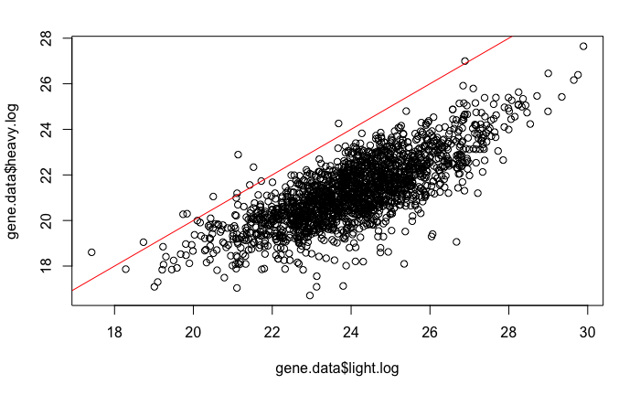

```
9.09% of input gene IDs are fail to map...'select()' returned 1:many mapping between keys and columns
5.21% of input gene IDs are fail to map...'select()' returned 1:many mapping between keys and columns
```

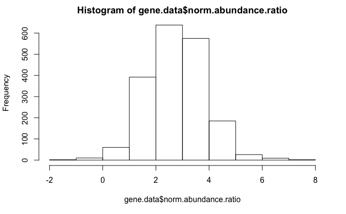

```r
# Calling the function 'enrichKEGG' on intersections of interest
across.9.kegg = enrichK(isect,280,agg.prot,0.05,outdir)
```

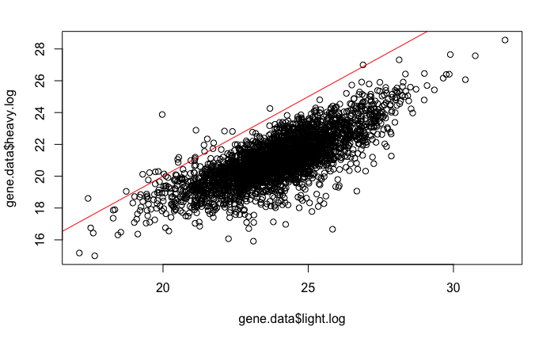

```
12.5% of input gene IDs are fail to map...'select()' returned 1:many mapping between keys and columns
6.23% of input gene IDs are fail to map...'select()' returned 1:many mapping between keys and columns
```

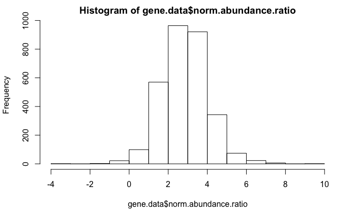

```r
across.150mJ = enrichK(add.int,"150mJ.1:150mJ.2:150mJ.3",agg.prot,0.05,outdir)
```

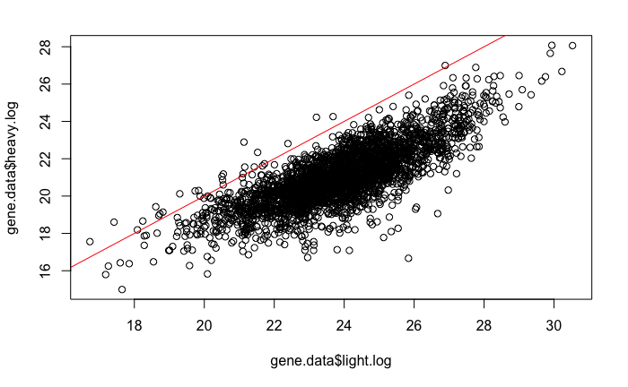

```
13.64% of input gene IDs are fail to map...'select()' returned 1:many mapping between keys and columns
5.59% of input gene IDs are fail to map...'select()' returned 1:many mapping between keys and columns
```

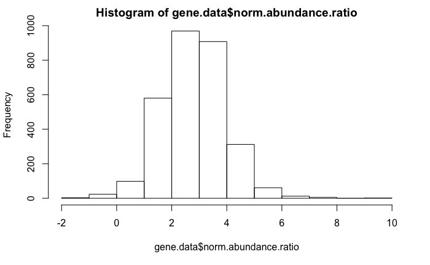

```r
across.275mJ = enrichK(add.int,"275mJ.1:275mJ.2:275mJ.3",agg.prot,0.05,outdir)
```

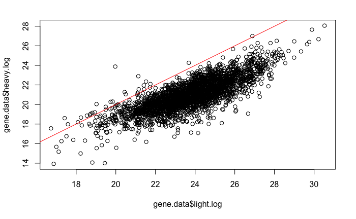

```
8.7% of input gene IDs are fail to map...'select()' returned 1:many mapping between keys and columns
6.9% of input gene IDs are fail to map...'select()' returned 1:many mapping between keys and columns
```

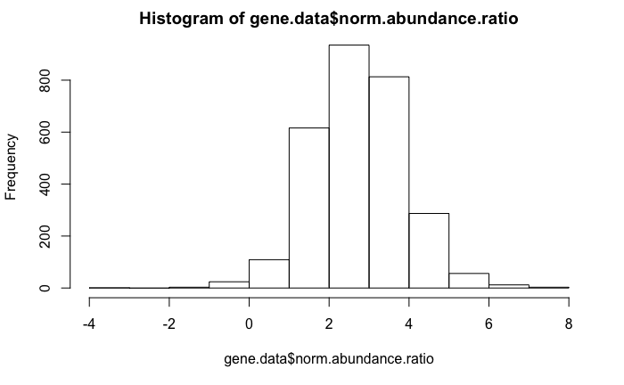

```r
across.400mJ = enrichK(add.int,"400mJ.1:400mJ.2:400mJ.3",agg.prot,0.05,outdir)
```

```r
# Binding enriched KEGG pathway outcomes for all comparisons into one data frame for output
all.kegg = rbind(across.9.kegg,across.150mJ,across.275mJ,across.400mJ)
write.table(all.kegg, paste(outdir,"KEGG-enrichment-for-enriched-proteins.txt",sep="/"),sep="\t",quote=F)
```

Not sure what to define the protein “universe” as. Used all of the proteins in the aggregaed list but this is not sufficient to run the KEGG analysis (throws a “not suffiecient members in group” error. Need to read a bit more about the inner workings of enrichKEGG to see if this can be changed.

Meanwhile, the overlapping proteins across all samples are enriched for the terms “Ribosome”,“Spliceosome”,“Protein processing in ER”,“Cell adhesion molecules” etc…Rayner concerned about presence of proteoglycans as these could be unwanted members entering the interface. Experiments are underway to check this.

I have also done an enrichment for proteins that were common within triplicate and each UV dosage. Get very similar terms as before (which is expected) and a few extra. The 150mJ dosage has the most number of significant KEGG mappings of the three dosages. There are a few pathways that aren’t enriched in the crosslinked sample (Down) but majority are. There are instances where the term “splisosome” appears in both enriched and un-enriched categories but the genes that contribute to this KEGG term are different in the enriched and unenriched cases. Might be worth pursuing these genes that in the unenriched category - they are heterogeneous nuclear riboneucleo protein and small nuclear ribonucleoprotein, RNA helicase and splicing factor subunit.

The 275mJ dosage has a high number of histones which map to pathways such as Systemic lupus erythematosus, Viral carcinogenesis, ECM-receptor interaction and Alcoholism which are a bit odd. If you remember, 275mJ has on average more proteins per sample than the other two time points. Perhaps this isn’t the ideal UV dosage for the study.

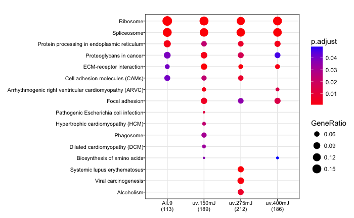